# Red Wine Quality by Arijit Mukherjee

## Data Description

```
##        X          fixed.acidity   volatile.acidity  citric.acid
##  Min.   :   1.0   Min.   : 4.60   Min.   :0.1200   Min.   :0.000
##  1st Qu.: 400.5   1st Qu.: 7.10   1st Qu.:0.3900   1st Qu.:0.090
##  Median : 800.0   Median : 7.90   Median :0.5200   Median :0.260
##  Mean   : 800.0   Mean   : 8.32   Mean   :0.5278   Mean   :0.271
##  3rd Qu.:1199.5   3rd Qu.: 9.20   3rd Qu.:0.6400   3rd Qu.:0.420
##  Max.   :1599.0   Max.   :15.90   Max.   :1.5800   Max.   :1.000
##  residual.sugar     chlorides       free.sulfur.dioxide
##  Min.   : 0.900   Min.   :0.01200   Min.   : 1.00
##  1st Qu.: 1.900   1st Qu.:0.07000   1st Qu.: 7.00
##  Median : 2.200   Median :0.07900   Median :14.00
##  Mean   : 2.539   Mean   :0.08747   Mean   :15.87
##  3rd Qu.: 2.600   3rd Qu.:0.09000   3rd Qu.:21.00
##  Max.   :15.500   Max.   :0.61100   Max.   :72.00
##  total.sulfur.dioxide    density             pH          sulphates
##  Min.   :  6.00       Min.   :0.9901   Min.   :2.740   Min.   :0.3300
##  1st Qu.: 22.00       1st Qu.:0.9956   1st Qu.:3.210   1st Qu.:0.5500
##  Median : 38.00       Median :0.9968   Median :3.310   Median :0.6200
##  Mean   : 46.47       Mean   :0.9967   Mean   :3.311   Mean   :0.6581
##  3rd Qu.: 62.00       3rd Qu.:0.9978   3rd Qu.:3.400   3rd Qu.:0.7300
##  Max.   :289.00       Max.   :1.0037   Max.   :4.010   Max.   :2.0000
##     alcohol         quality
##  Min.   : 8.40   Min.   :3.000
##  1st Qu.: 9.50   1st Qu.:5.000
##  Median :10.20   Median :6.000
##  Mean   :10.42   Mean   :5.636
##  3rd Qu.:11.10   3rd Qu.:6.000
##  Max.   :14.90   Max.   :8.000
```

```
## 'data.frame':    1599 obs. of  13 variables:
##  $ X                   : int  1 2 3 4 5 6 7 8 9 10 ...
##  $ fixed.acidity       : num  7.4 7.8 7.8 11.2 7.4 7.4 7.9 7.3 7.8 7.5 ...
##  $ volatile.acidity    : num  0.7 0.88 0.76 0.28 0.7 0.66 0.6 0.65 0.58 0.5 ...
##  $ citric.acid         : num  0 0 0.04 0.56 0 0 0.06 0 0.02 0.36 ...
##  $ residual.sugar      : num  1.9 2.6 2.3 1.9 1.9 1.8 1.6 1.2 2 6.1 ...
##  $ chlorides           : num  0.076 0.098 0.092 0.075 0.076 0.075 0.069 0.065 0.073 0.071 ...
##  $ free.sulfur.dioxide : num  11 25 15 17 11 13 15 15 9 17 ...
##  $ total.sulfur.dioxide: num  34 67 54 60 34 40 59 21 18 102 ...
##  $ density             : num  0.998 0.997 0.997 0.998 0.998 ...
##  $ pH                  : num  3.51 3.2 3.26 3.16 3.51 3.51 3.3 3.39 3.36 3.35 ...
##  $ sulphates           : num  0.56 0.68 0.65 0.58 0.56 0.56 0.46 0.47 0.57 0.8 ...
##  $ alcohol             : num  9.4 9.8 9.8 9.8 9.4 9.4 9.4 10 9.5 10.5 ...
##  $ quality             : int  5 5 5 6 5 5 5 7 7 5 ...
```

# Univariate Plots Section

Our Dataset has 12 varriables with 1599 obserbvation of different red wines

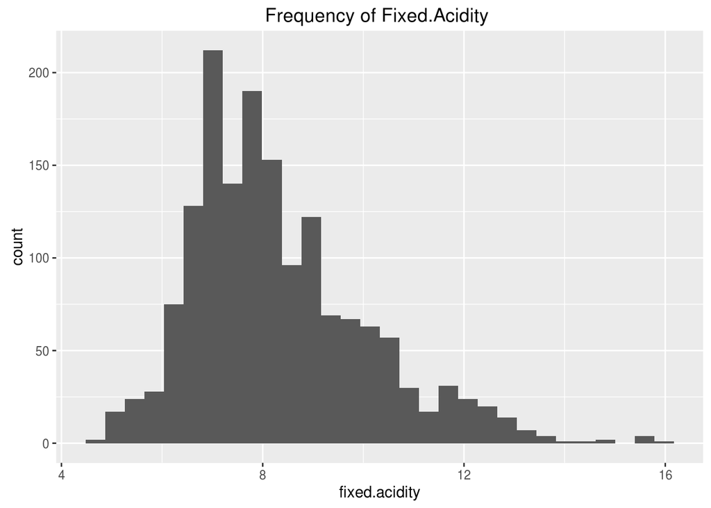

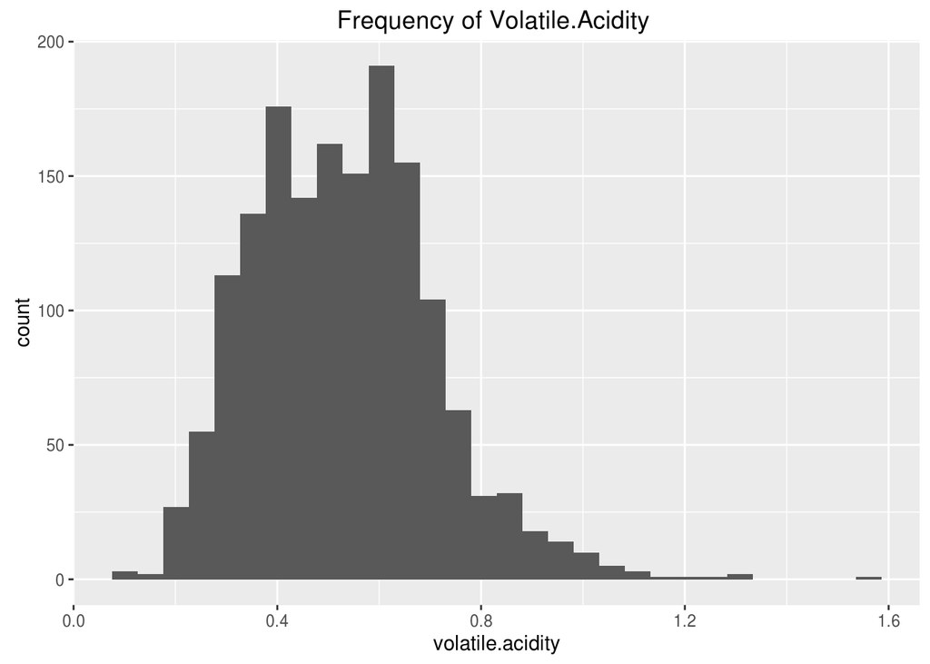

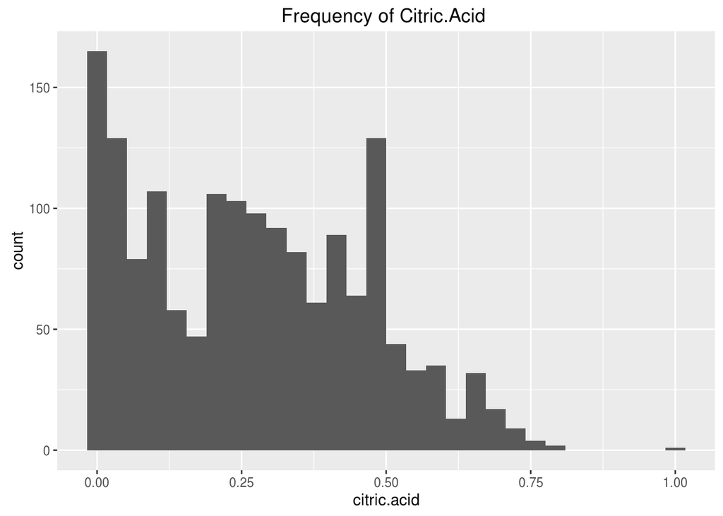

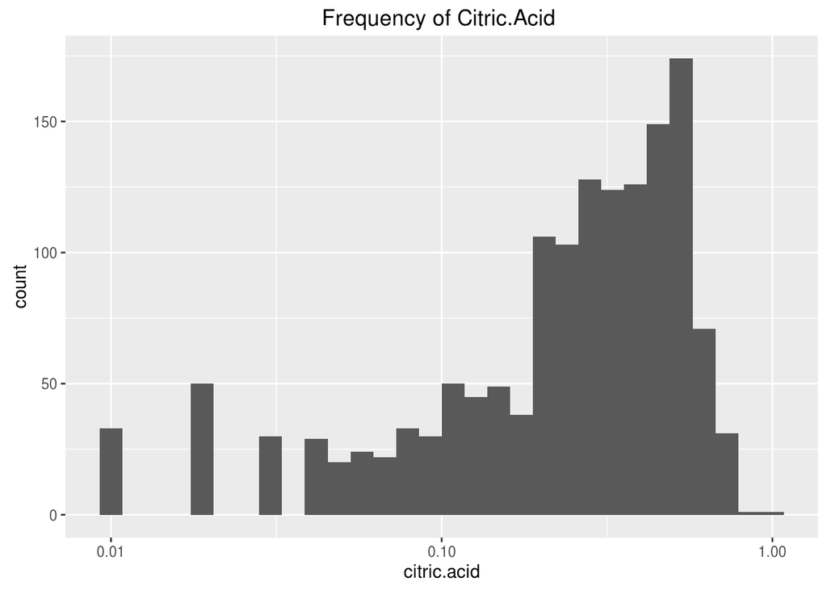

Citric Acidity looks skewed . . adding a log10 transformation wont change much .

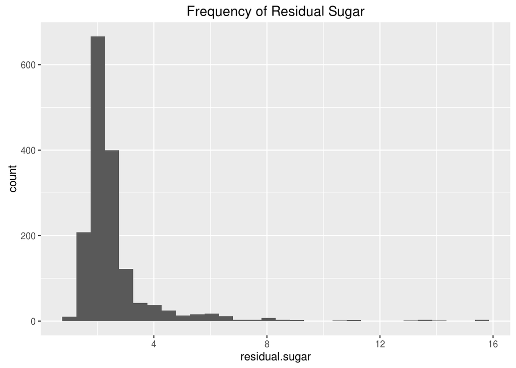

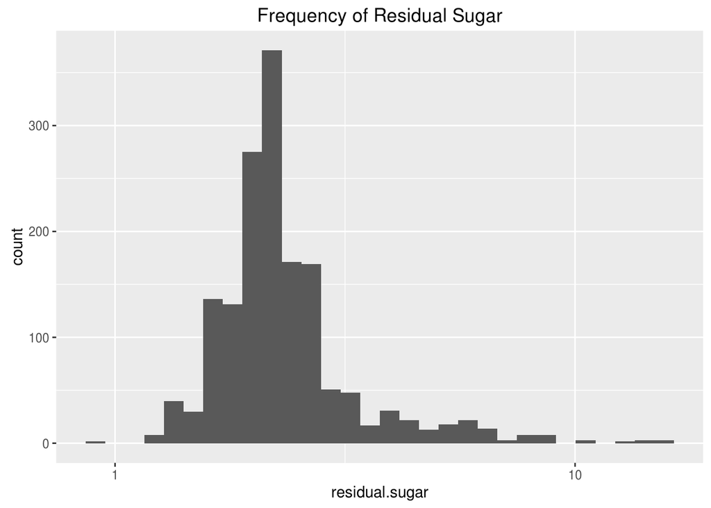

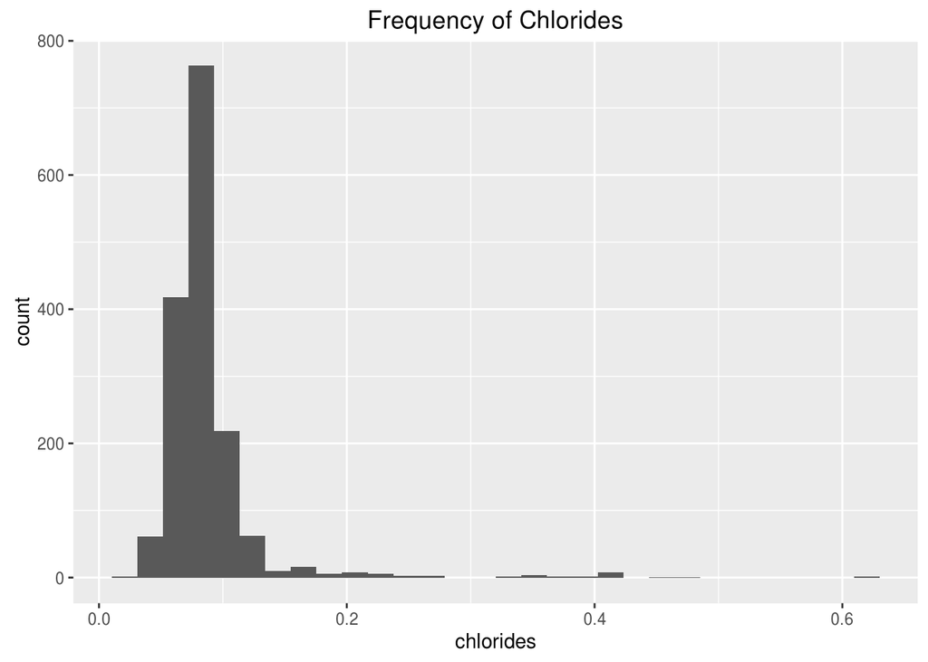

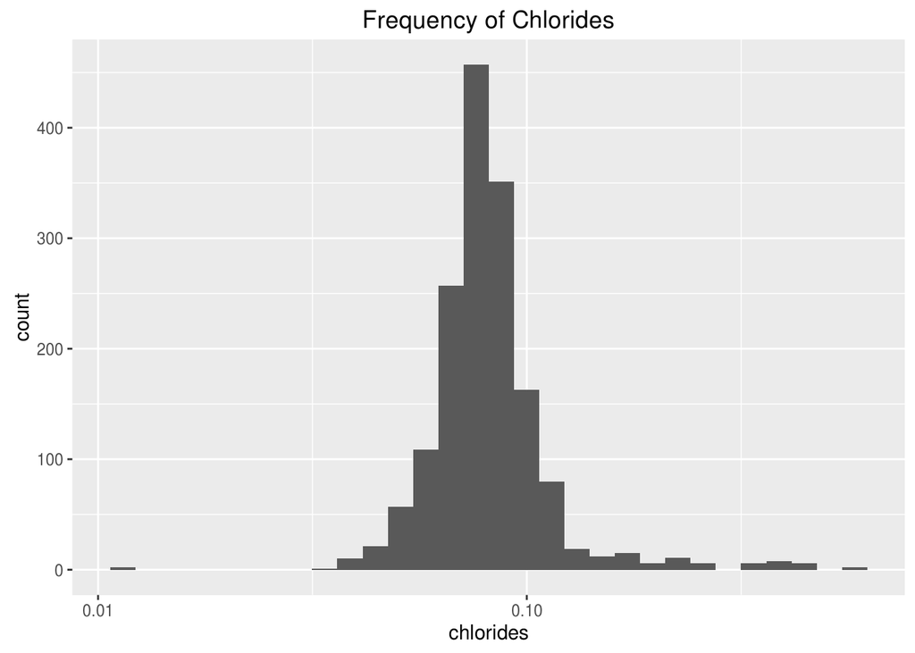

Residual Sugar looks Skewed adding a log10() transform wont change much on the other hand Cholrides distribution looks skewed but adding a log10 transform makes it normal distributed with a right tail

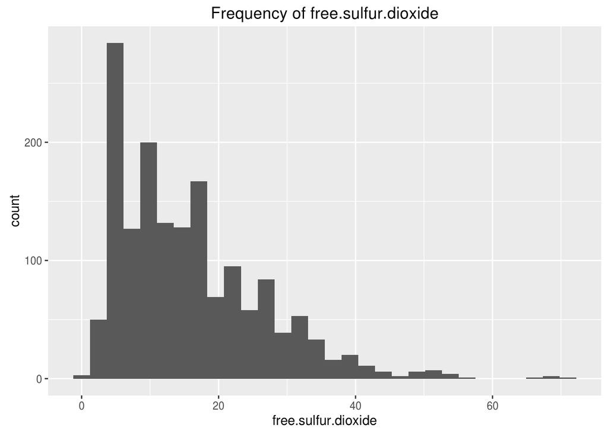

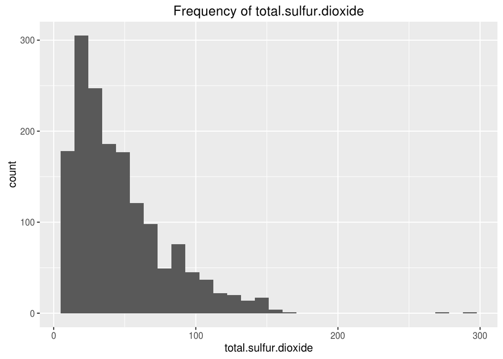

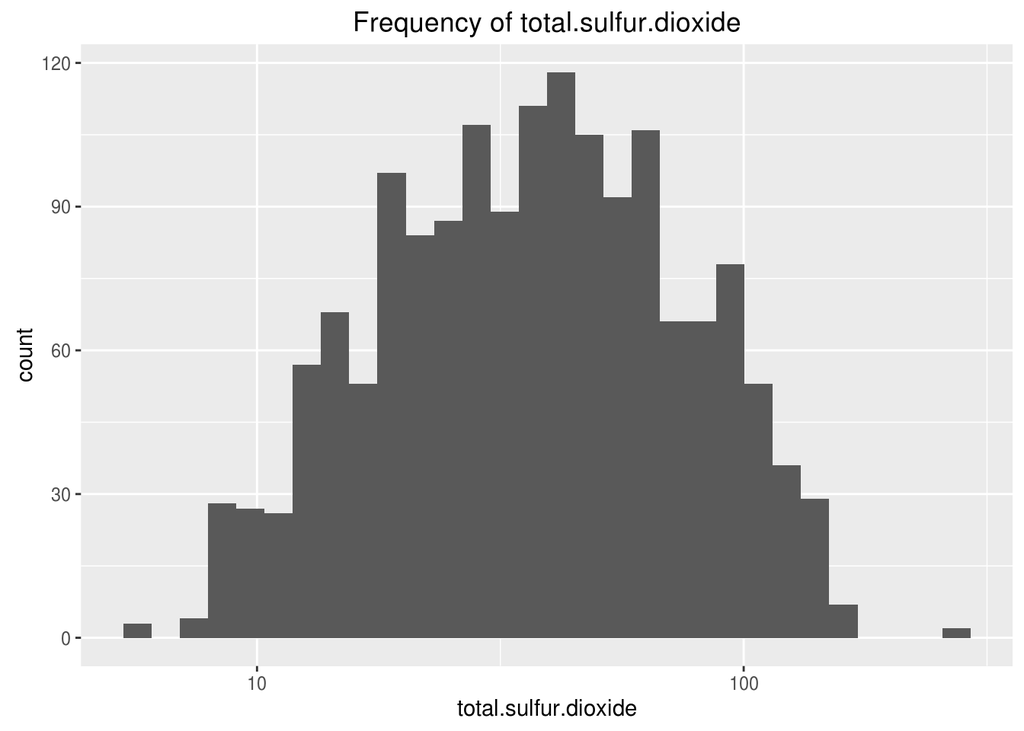

Adding log10() transformation on X axis makes the distribution Normal for Total.sulfur.dioxide

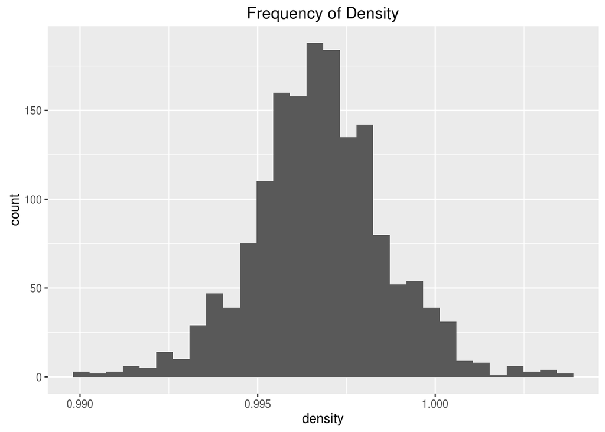

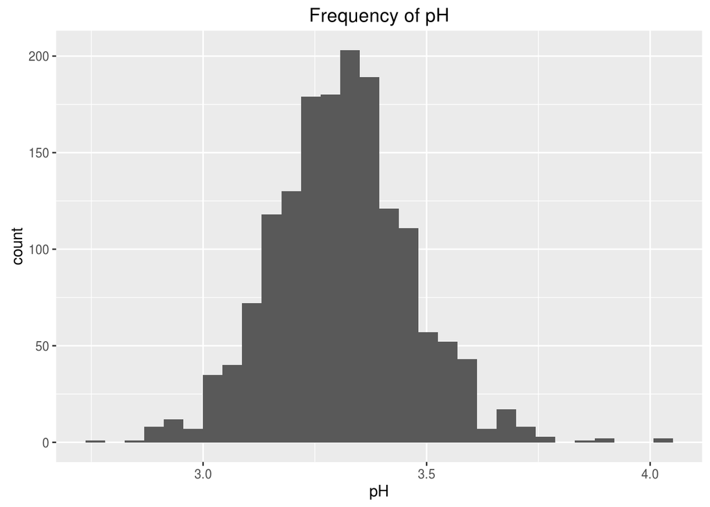

pH and Density is normally distrbuted

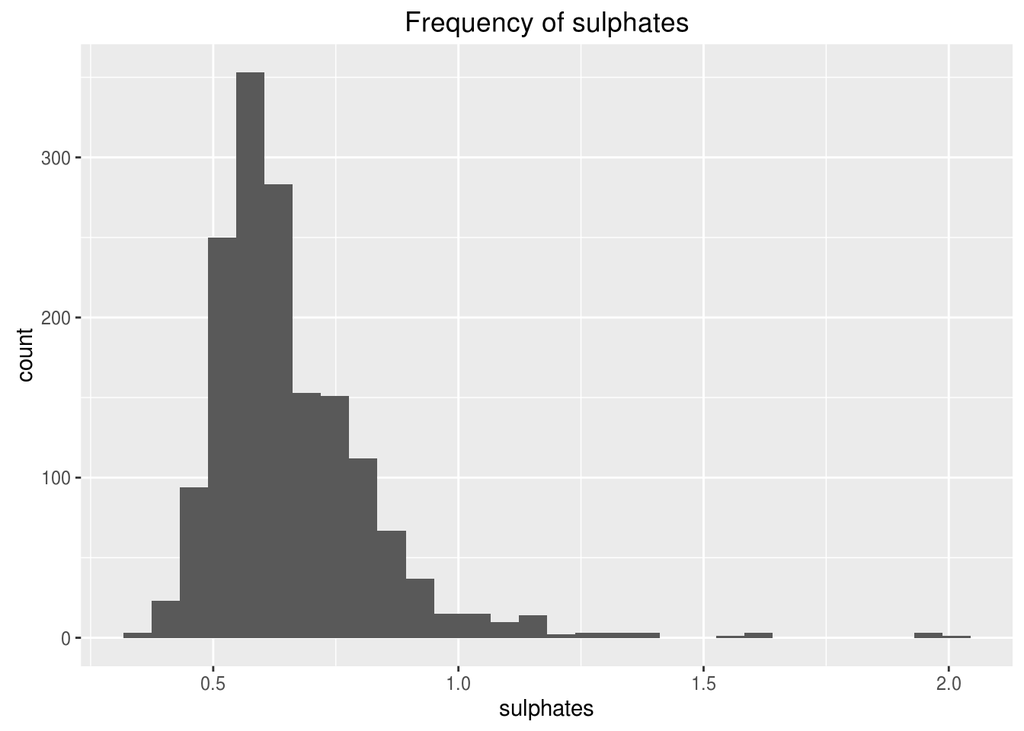

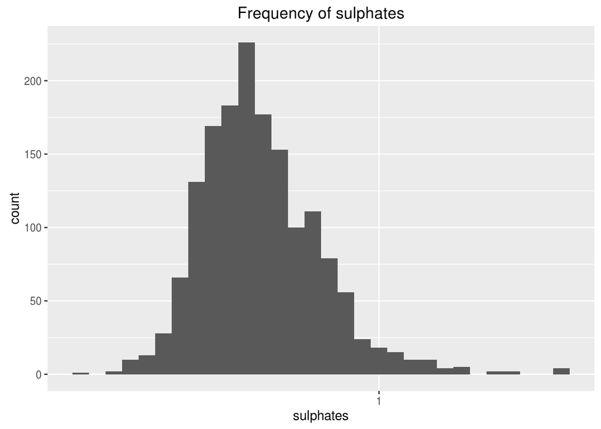

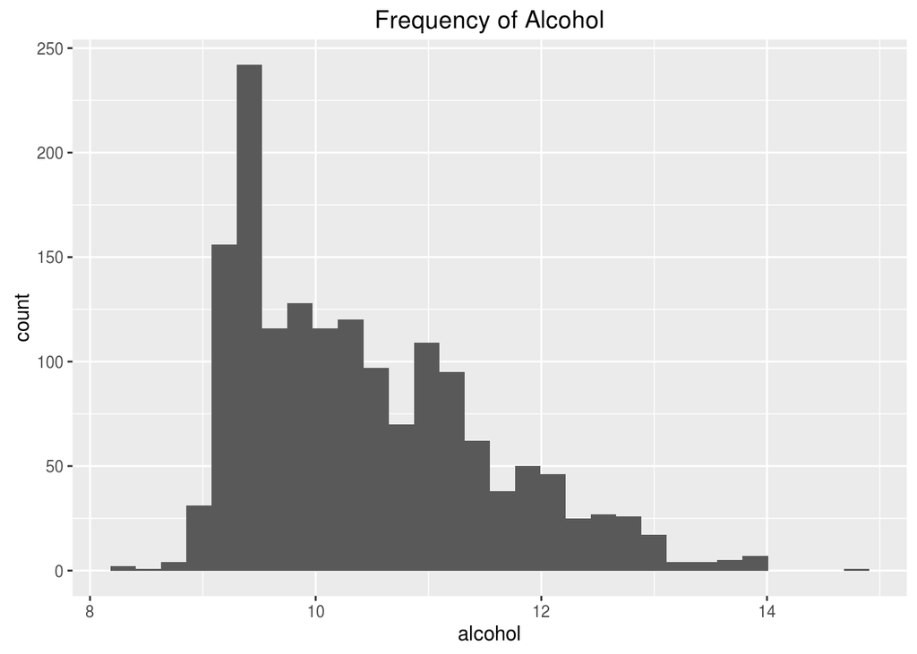

Frequency of Sulphate looks normally distributed after adding log10() transformation

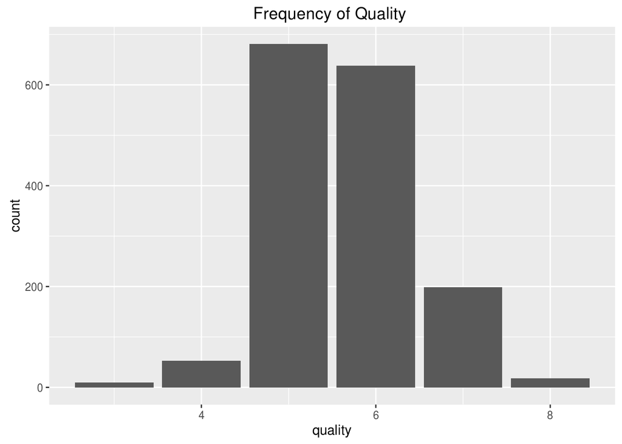

# Univariate Analysis

### What is the structure of your dataset?

Number of Records: 1599  
Number of Attributes: 11 + output attribute  
Attribute information: Input Variable 1 - fixed acidity (tartaric acid - g / dm^3) 2 - volatile acidity (acetic acid - g / dm^3) 3 - citric acid (g / dm^3) 4 - residual sugar (g / dm^3) 5 - chlorides (sodium chloride - g / dm^3 6 - free sulfur dioxide (mg / dm^3) 7 - total sulfur dioxide (mg / dm^3) 8 - density (g / cm^3) 9 - pH 10 - sulphates (potassium sulphate - g / dm3) 11 - alcohol (% by volume) Output variable (based on sensory data): 12 - quality (score between 0 and 10)

### What is/are the main feature(s) of interest in your dataset?

Quality is the main feature of interest in this dataset

### What other features in the dataset do you think will help support your investigation into your feature(s) of interest?

The information provided by the authors that there are correlation between certain features. Thus we look into the feature which effects the quality and as there are much more number of Wines of average quality than very low and very high quality wines it will be a task to dected the outliers to find the excelent and poor quality wines.

### Did you create any new variables from existing variables in the dataset?

No , I didn’t created any new variables from existing variables in the dataset.

### Of the features you investigated, were there any unusual distributions? Did you perform any operations on the data to tidy, adjust, or change the form of the data? If so, why did you do this?

Citric Acidity looked unusally distributed but adding log-transform it wont change much. Total.sulfur.dioxide and Frequency of Sulphate looked skewed but adding a log10 transformation changed the form of the data to normally distributed .

# Bivariate Plots Section

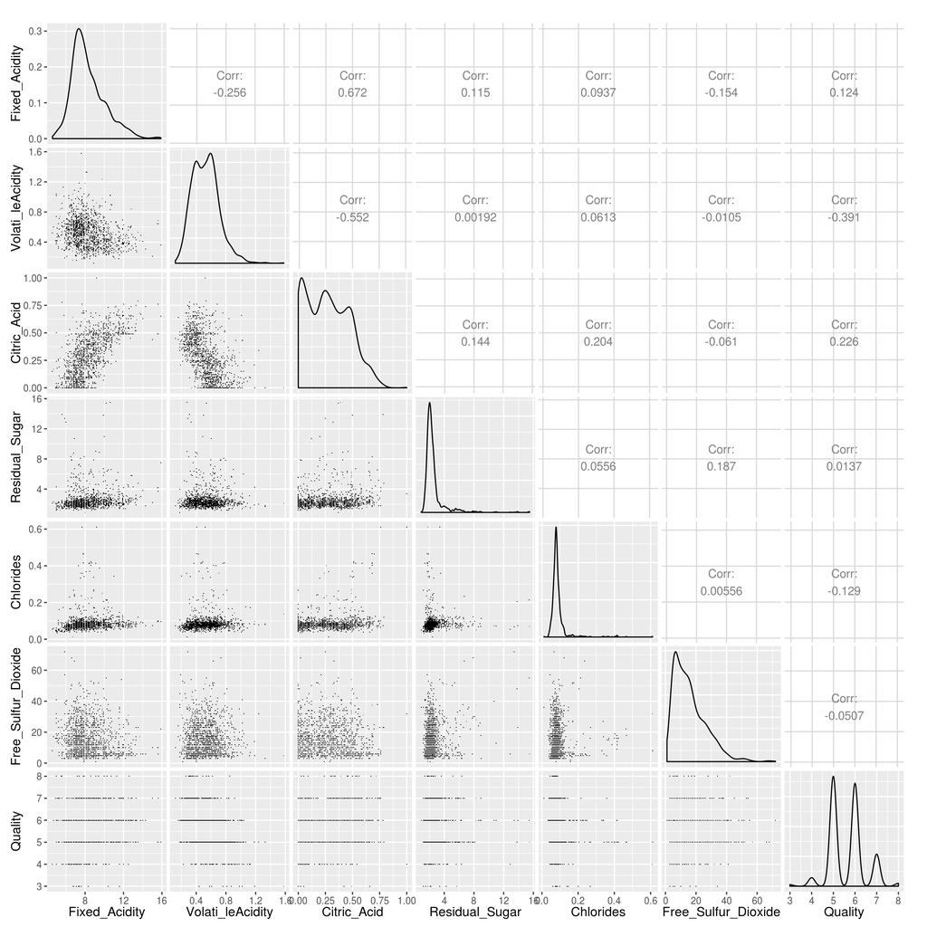

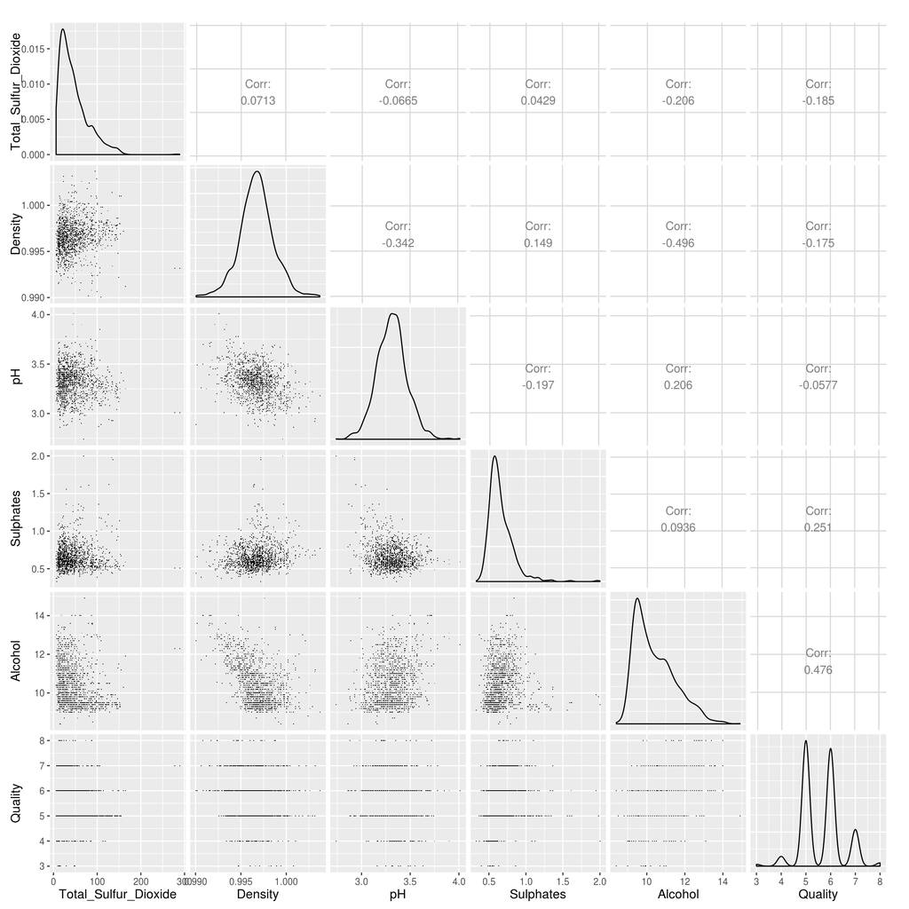

From the above pairs we can see a scatter plot for each pair and a Correlation Coefficient for each pair . Here we select 4 attributes which have high correlation with Quality and will discuss them furthur . These four attributes are Alcohol,Volatile Acidity , Citric Acid and Sulphates .

```
##
##  Pearson's product-moment correlation
##
## data:  red_wine$quality and red_wine$alcohol
## t = 21.639, df = 1597, p-value < 2.2e-16
## alternative hypothesis: true correlation is not equal to 0
## 95 percent confidence interval:
##  0.4373540 0.5132081
## sample estimates:
##       cor
## 0.4761663
```

```
##
##  Pearson's product-moment correlation
##
## data:  red_wine$quality and red_wine$volatile.acidity
## t = -16.954, df = 1597, p-value < 2.2e-16
## alternative hypothesis: true correlation is not equal to 0
## 95 percent confidence interval:
##  -0.4313210 -0.3482032
## sample estimates:
##        cor
## -0.3905578
```

```
##
##  Pearson's product-moment correlation
##
## data:  red_wine$quality and red_wine$sulphates
## t = 10.38, df = 1597, p-value < 2.2e-16
## alternative hypothesis: true correlation is not equal to 0
## 95 percent confidence interval:
##  0.2049011 0.2967610
## sample estimates:
##       cor
## 0.2513971
```

```
##
##  Pearson's product-moment correlation
##
## data:  red_wine$quality and red_wine$citric.acid
## t = 9.2875, df = 1597, p-value < 2.2e-16
## alternative hypothesis: true correlation is not equal to 0
## 95 percent confidence interval:
##  0.1793415 0.2723711
## sample estimates:
##       cor
## 0.2263725
```

The Correlation of these four attributes with Quality is as follows

**Alcohol (Corr : .476)**  
**Volatile.Acidity (Corr : -.391)**  
**Sulphates (Corr : .251)**  
**Citric.Acid (Corr : .226)**

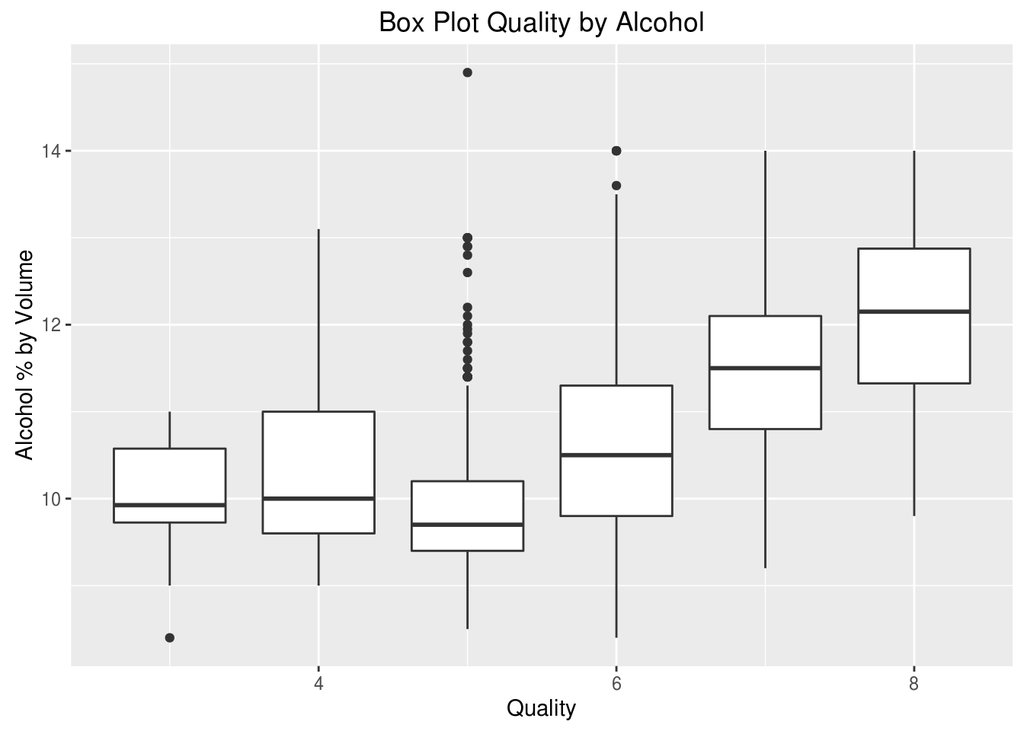

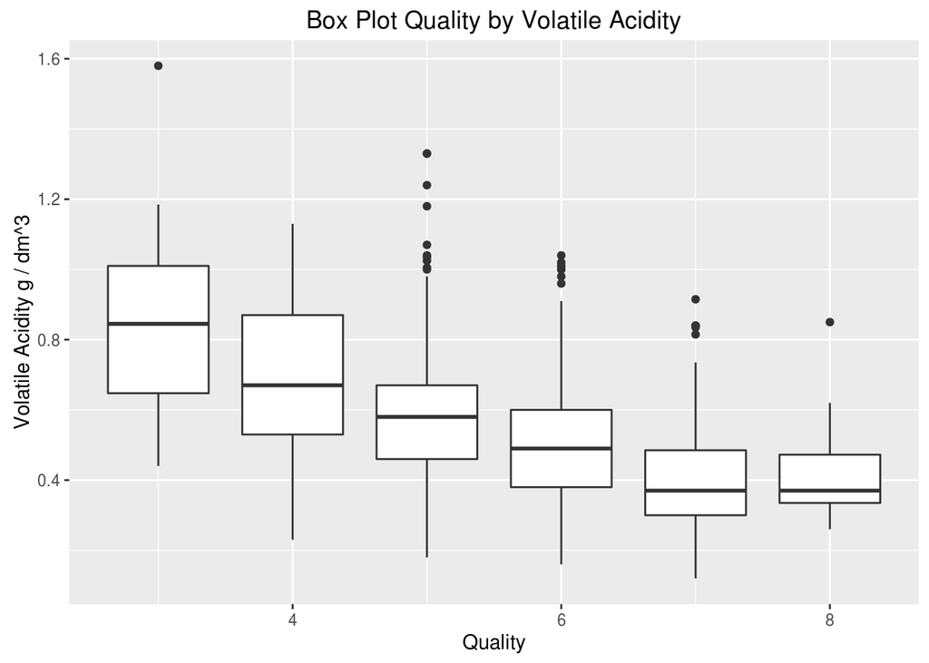

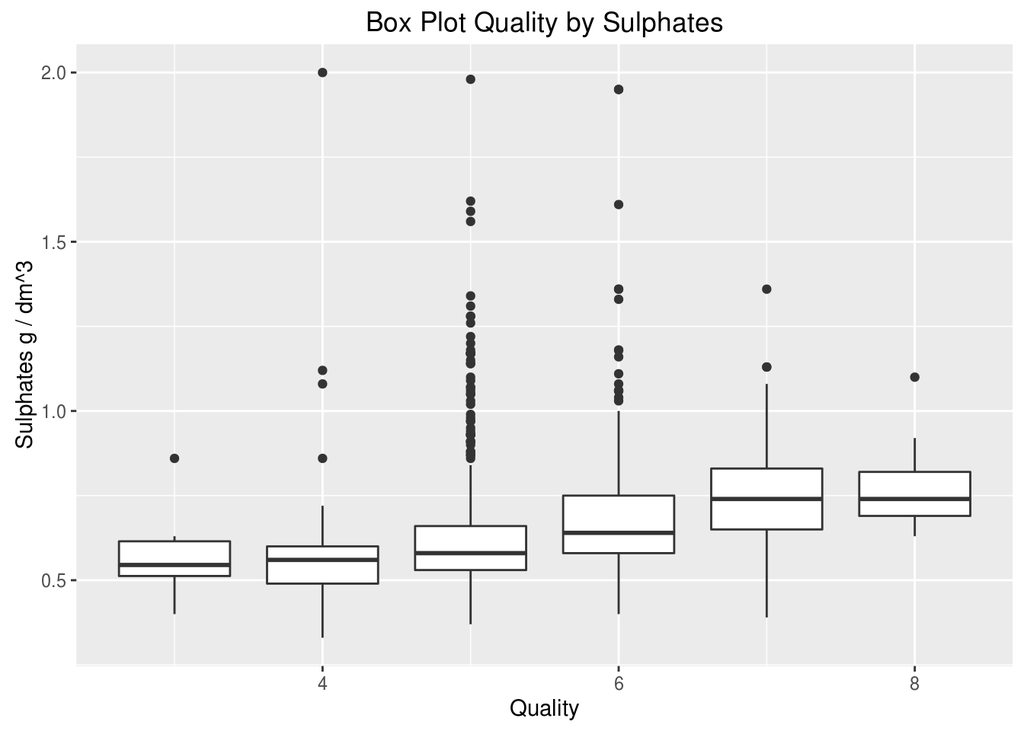

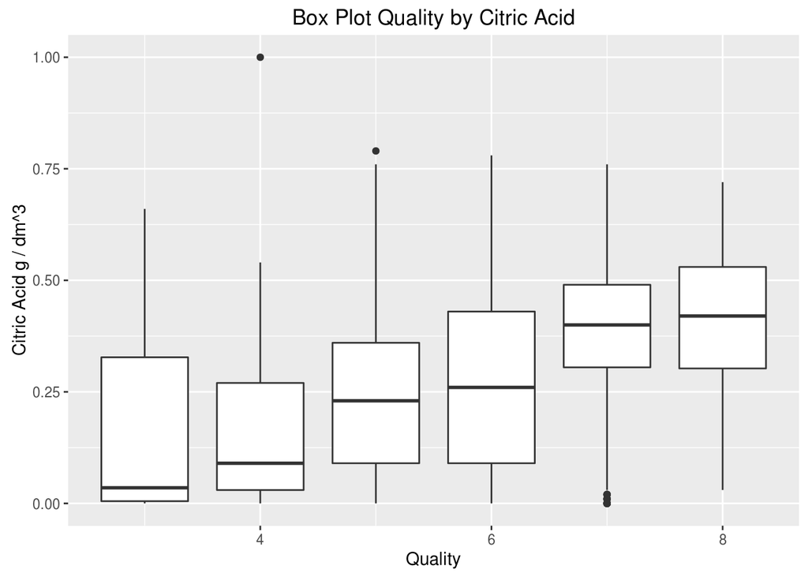

For Alcohol the mean is relatively higher for the High Quality wines than the lower quality wines. In case of Volatile Acidity we can see a distinct feature that for the low Quality Wines Volatile Acidity is much higher that of the medium and High Quality Wines

The mean of Sulphates and Citric Acid are in high both cases for high Quality Wines . From the above box plots its clear that The attributes Alcohol and Volatile Acidity contributes the most in Quality while Citric Acid and Sulphates also have some effects on the Quality.

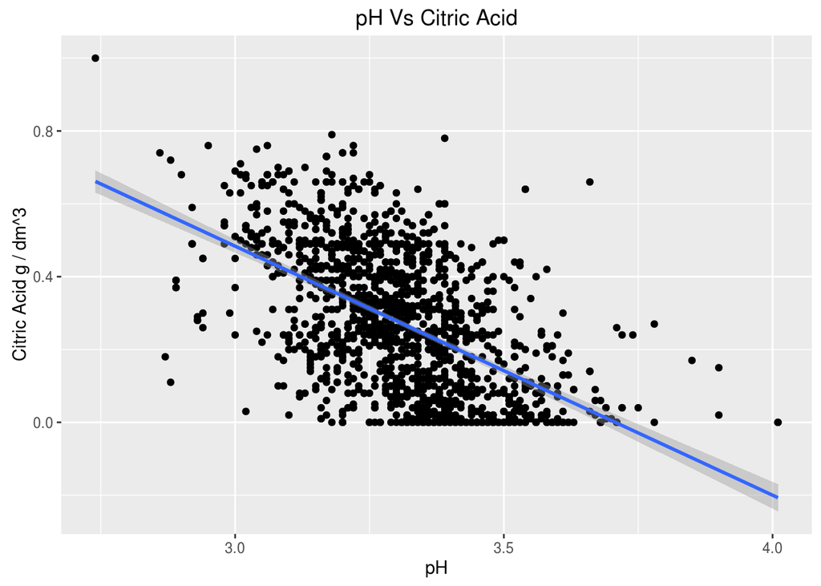

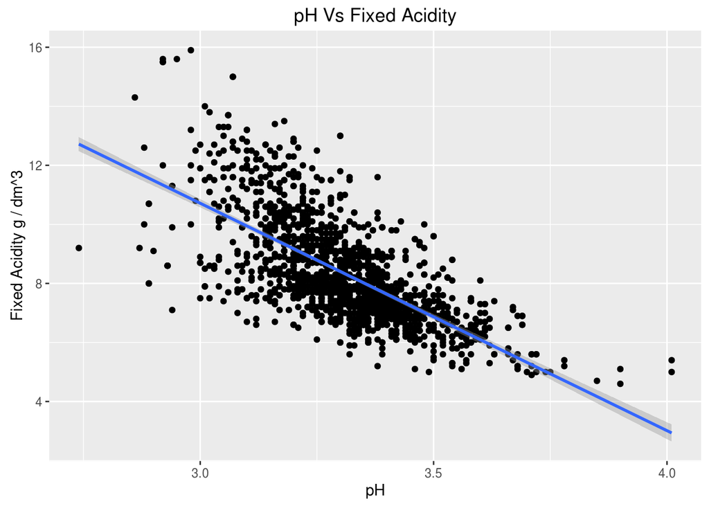

```
##
##  Pearson's product-moment correlation
##
## data:  red_wine$pH and red_wine$fixed.acidity
## t = -37.366, df = 1597, p-value < 2.2e-16
## alternative hypothesis: true correlation is not equal to 0
## 95 percent confidence interval:
##  -0.7082857 -0.6559174
## sample estimates:
##        cor
## -0.6829782
```

```
##
##  Pearson's product-moment correlation
##
## data:  red_wine$pH and red_wine$citric.acid
## t = -25.767, df = 1597, p-value < 2.2e-16
## alternative hypothesis: true correlation is not equal to 0
## 95 percent confidence interval:
##  -0.5756337 -0.5063336
## sample estimates:
##        cor
## -0.5419041
```

One intersting effect is on pH as it measures the level of acidity of a solution we can see pH has high correlation values with Fixed Acidity and Citric Acid.

# Bivariate Analysis

### Talk about some of the relationships you observed in this part of the investigation. How did the feature(s) of interest vary with other features in the dataset?

It looks like For all high quality Red wine the mean of alcohol,sulphates,citric.acid is relatively higher than the low quality Red wine samples .

And For volatile.acidity the level is relatively lower in the high quality products than the lower ones

### Did you observe any interesting relationships between the other features (not the main feature(s) of interest)?

There is high correlation between pH and both citric.acid and fixed.acidity as pH indirectly measures the acidity of a soultion.  
**Correlation**  
pH —– Citric.Acid : -.542  
pH —– Fixed.Acidity : -.683

This means with increase of Citric.Acid and Fixed.Acidity pH levels decreases.

### What was the strongest relationship you found?

Alcohol and Quality  
pH and Fixed.Acidity

# Multivariate Plots Section

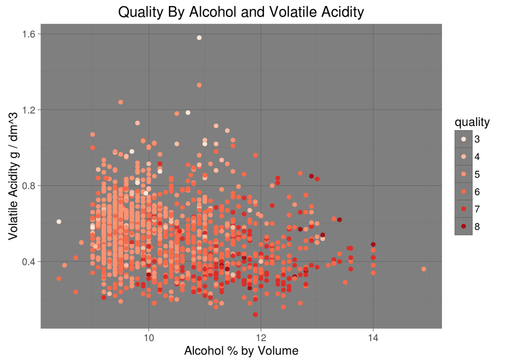

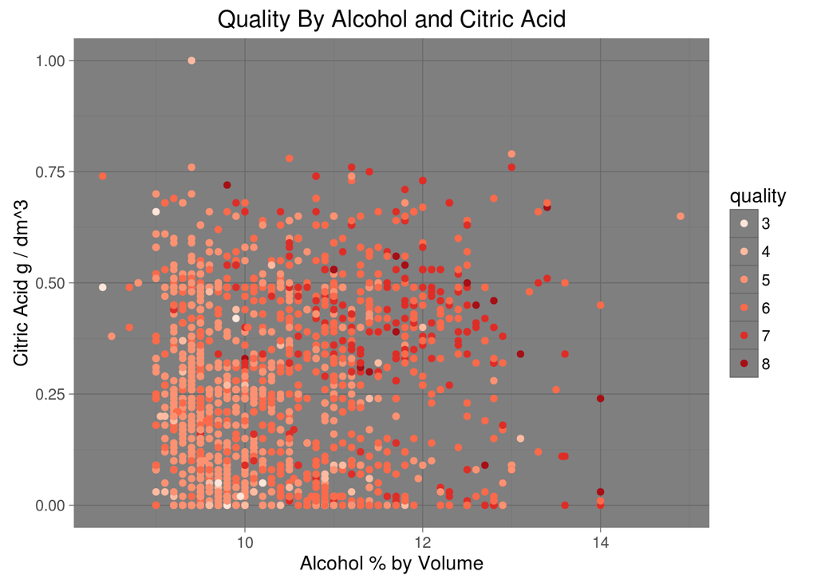

[figure not shown]

Now we can see the realtions between Quality and the other variables which effect the quality but due to many obverbvations belonging from the midum quality samples its tough to draw some decision from the above visualizations so lets subset the dataframe without the 5,6 quality wines

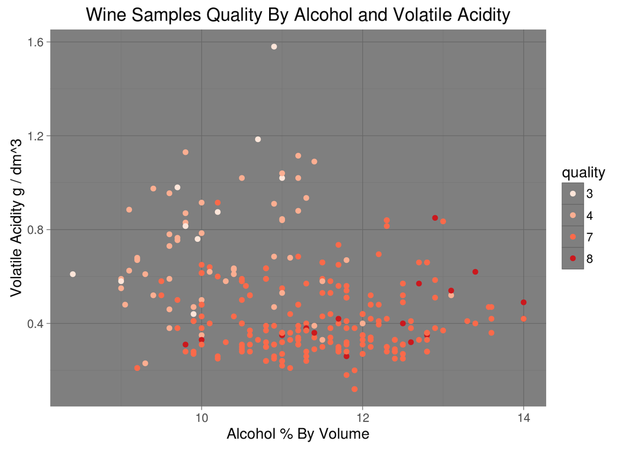

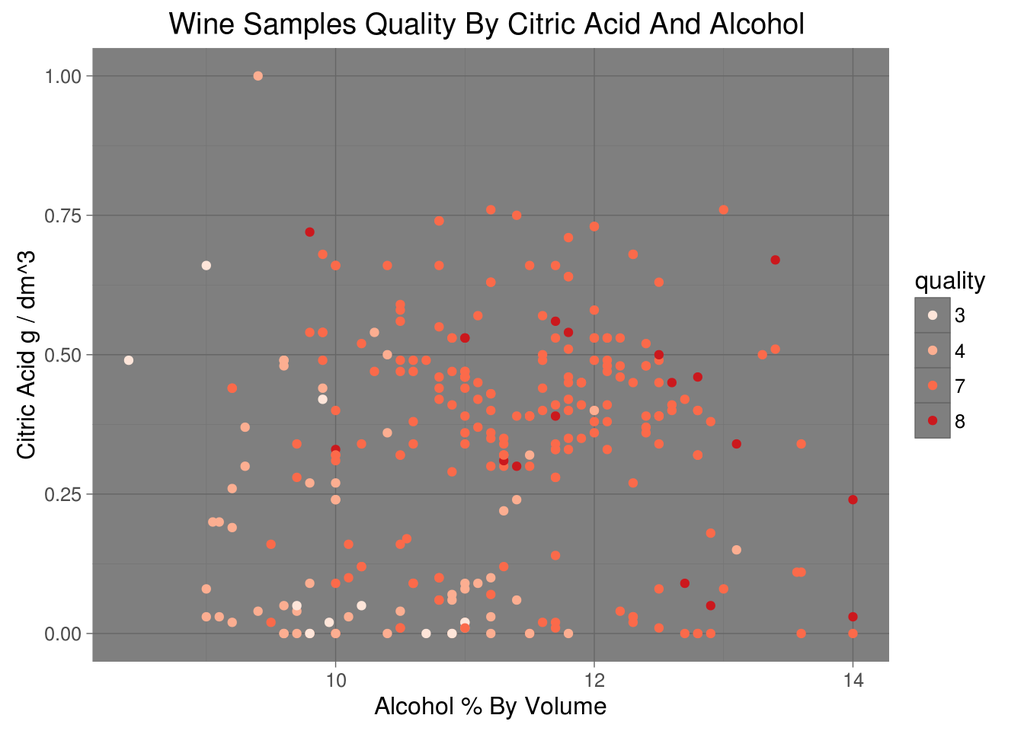

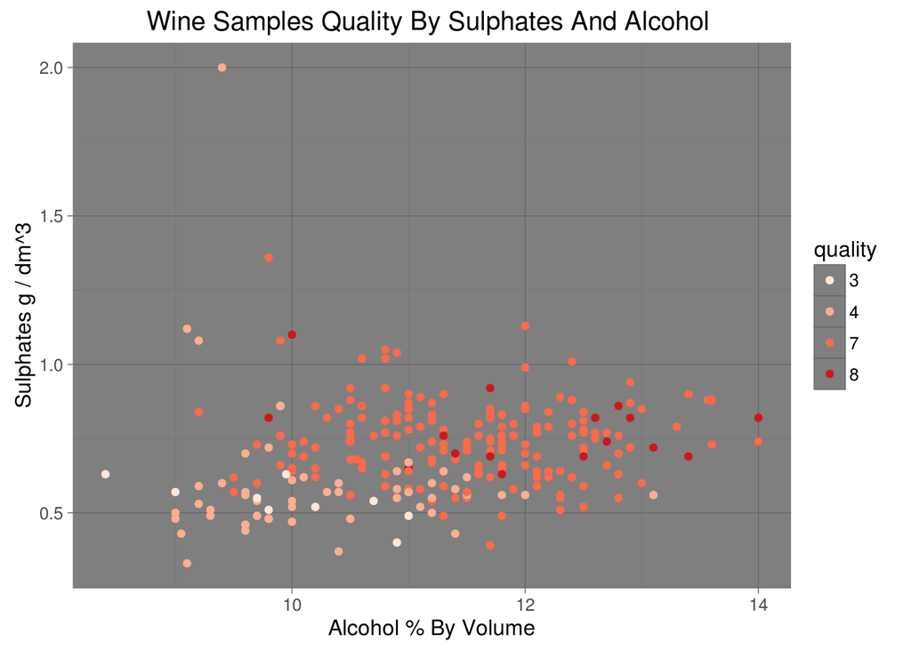

Now lets draw two visualization to relate Quality-Citric.Acid-Alcohol-Volatile.Acidity and Quality-Sulphates-Alcohol-Volatile.Acidity

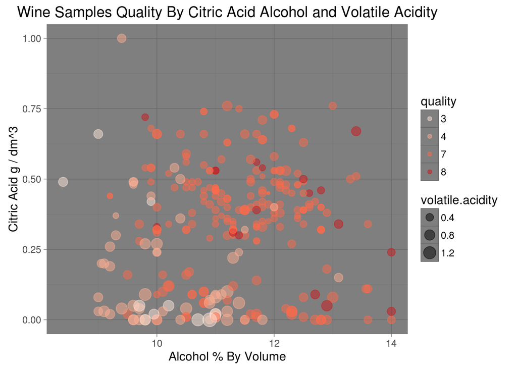

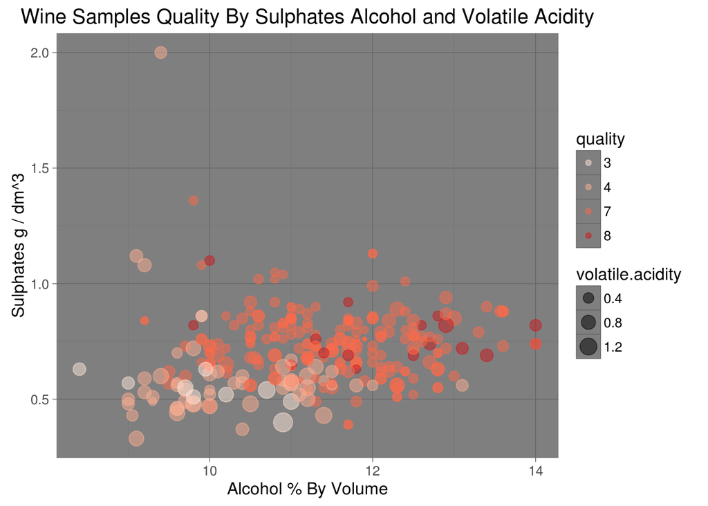

# Multivariate Analysis

### Talk about some of the relationships you observed in this part of the investigation. Were there features that strengthened each other in terms of looking at your feature(s) of interest?

Most of the High Quality Wines have high level of Alcohol-Citric.Acid-Sulphates and Low level of Volatile.Acidity

### Were there any interesting or surprising interactions between features?

With much high level of Alcohol and low level of Citric.Acid some of the samples were of High Quality .

### OPTIONAL: Did you create any models with your dataset? Discuss the strengths and limitations of your model.

# Final Plots and Summary

### Plot One

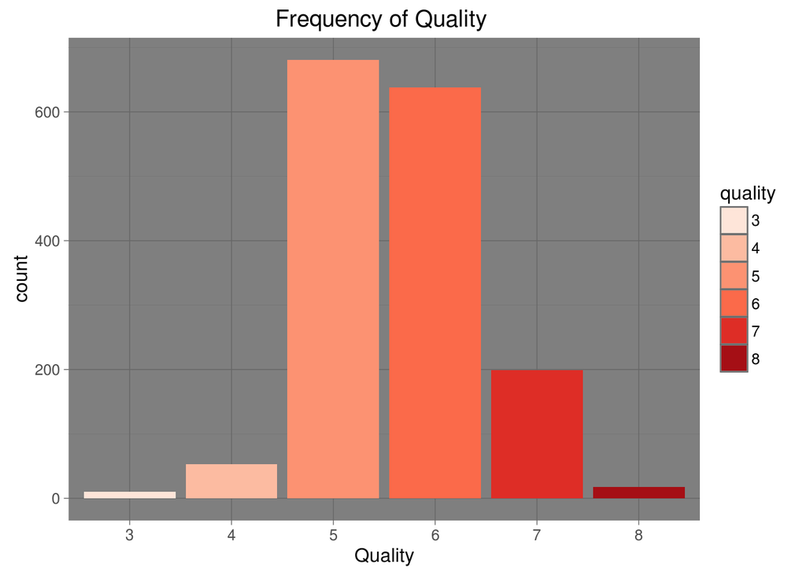

```
##   3   4   5   6   7   8
##  10  53 681 638 199  18
```

### Description One

In the total 1599 samples most of the samples were of medium quality. There were only 10 samples of quality 3 and only 18 samples of quality 8 most of them were in either 5 or 6. The Quality is approximately normally distributed .

### Plot Two

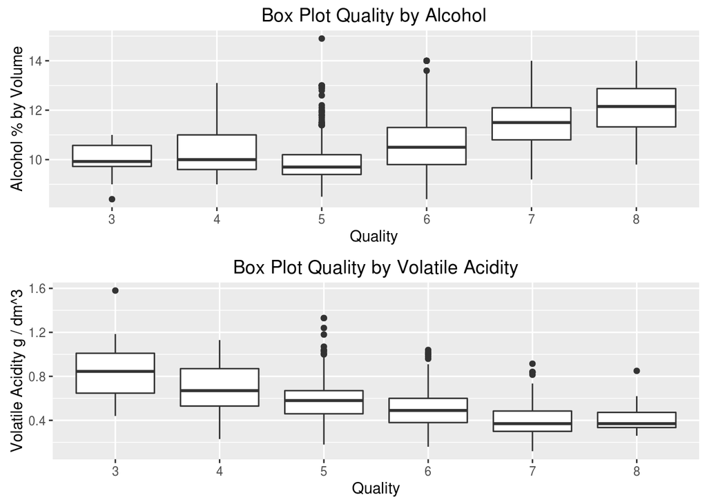

```
##
##  Pearson's product-moment correlation
##
## data:  red_wine$quality_i and red_wine$alcohol
## t = 21.639, df = 1597, p-value < 2.2e-16
## alternative hypothesis: true correlation is not equal to 0
## 95 percent confidence interval:
##  0.4373540 0.5132081
## sample estimates:
##       cor
## 0.4761663
```

```
##
##  Pearson's product-moment correlation
##
## data:  red_wine$quality_i and red_wine$volatile.acidity
## t = -16.954, df = 1597, p-value < 2.2e-16
## alternative hypothesis: true correlation is not equal to 0
## 95 percent confidence interval:
##  -0.4313210 -0.3482032
## sample estimates:
##        cor
## -0.3905578
```

### Description Two

The above plot shows the 2 main component that have high effects on the quality . The Alchol - Volatile.Acidity determines the quality of the wine . The high Quality Wines have relatively high mean of Alcohol % than the lower quality ones and The low Quality wines have much higher mean of Volatile Acidity than the High Quality Wines .

### Plot Three

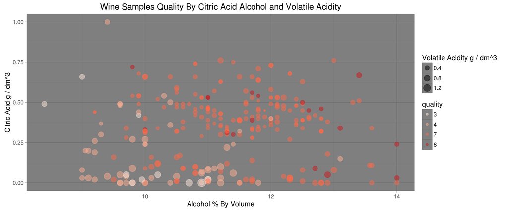

# Reflection

In the dataset there were 1599 observation in which we tried to find the effect of chemical factors on the quality of the wine . Alcohol and Volatile.Acidity has the strongest effect on the quality of a wine . While the hihg level of Alchol indicates a high quality wine on the other hand high level of Volatile.Acidity can make the quality of the wine degrade. Quality is proportional to the level of alcohol and The Quality is inversly proportional to the Level of Volatile Acidity . The next dominant factors are the Citric.Acid and Sulphates . Citric.Acid have some effects on the quality of wine but high Volatile.Acidity can degrade the quality of wine even with high level of Citric.Acid . Firstly we selected the main dependent Variable The Quality and we tried to find which attributes have most effects to the Quality . Finally we narrowed down to 3 Variables Alcohol,Volatile Acidity and Citric Acid . We used correlation between them to find the effects of these attributes on Quality. The most challengeing part of the dataset is The Quality is a sensory measurement which can change drastically from human to human as the rating of quality is given by Humans . In the future we can train a Linear Model to predict the quality of a Wine from various attributes like the Alcohol,Volatile Acidity,Citric Acid and Sulphates.